# Introdução ao R

## O que é o R?

- Linguagem de programação
- Análise estatística
- Visualização de dados

| R | SPSS, jamovi, jasp… |
| --- | --- |
| Menos amigo do utilizador (syntax-based) | Mais amigo do utilizador (point-and-click) |
| Procedimentos estatísticos ilimitados | Procedimentos estatísticos limitados |
| Programação aberta e flexível | Programação (relativamente) fechada |

## Baixar e Instalar o R e RStudio

O R e RStudio estão disponíveis de forma livre:  
1. [Download R](http://cran.r-project.org/)  
2. [Download RStudio](https://posit.co/download/rstudio-desktop/)

O R e RStudio são compatíveis com os principais OS’s:  
- PC  
- MAC  
- Linux

**RECOMENDAÇÃO:**  
*Primeiro instalar o R e só depois o RStudio*

## Ambiente R

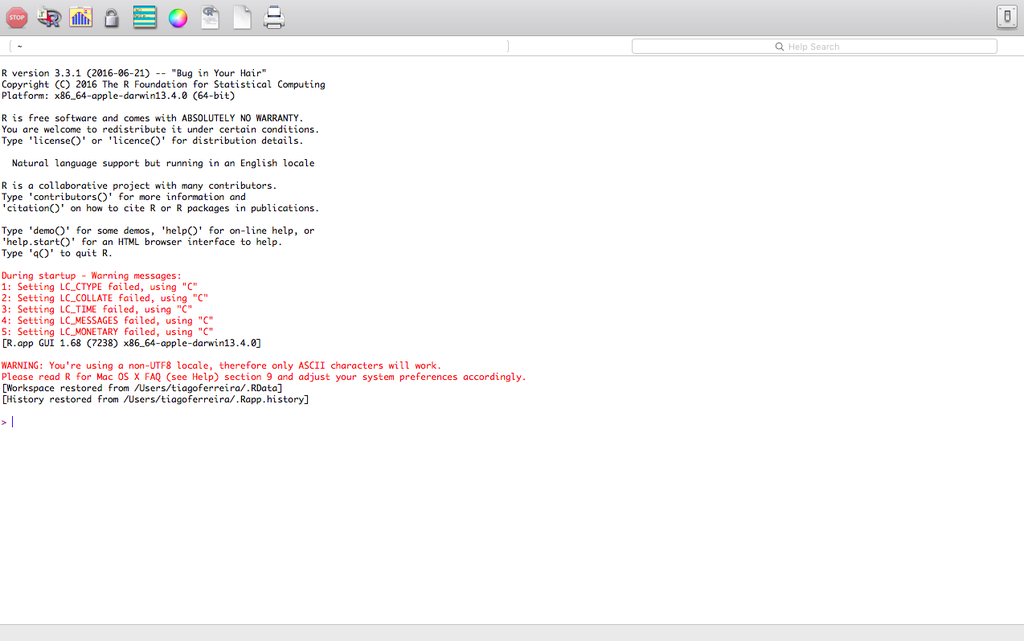

A instalação básica recurso que permitem:  
- Criar diferentes tipos de estruturas de dados  
- Editar e gerir dados  
- Analisar e visualizar dados  
- Pacotes adicionais disponíveis para utilização livre em [CRAN](https://www.r-project.org/).*

## O RStudio (IDE)

Razões para utilizar o RStudio:  
- Torna mais fácil a produção de scripts (code completion)  
- Facilita a edição e execução do código R  
- Acesso facilitado (interface gráfico) a muitas funcionalidades do R  
- Permite criar e partilhar projetos R  
- Torna outputs mais acessíveis  
- Inclui um interface para produção de relatórios em diversos formatos (RMarkdown)  
- [e muito mais…](https://www.r-bloggers.com/top-6-reasons-you-need-to-be-using-rstudio/)

## O RStudio

[figure not shown]

## O R tem uma curva de aprendizagem longa

[figure not shown]

## AGENDA

### Breve introdução ao R e RStudio

- **Funcionamento básico do R e RStudio**
- **Operadores e objetos**
- **Estruturas de dados**
- **Funções integradas**
- **Pacotes R**

## Funcionamento básico do R e RStudio

## Funções no R

- As funcionalidades do R estão acessíveis por meio de **funções**
  - *Conjunto de operações combinadas para realizar uma tarefa específica*
- Estrutura geral de um função:
  - **Nome.da.função**
  - **Diferentes argumentos (arg1, arg2, …)**
  - **O resultado de uma função pode ser usada para criar um novo objeto**

```r
print("Olá!")
```

```
## [1] "Olá!"
```

*“Run” ou atalho “ctrl + enter” para executar o código R*

## Sessão de trabalho no R

- Definida por um diretório ou pasta de trabalho (**working directory - WD**)
  - O WD está localizado no nosso computador
  - Serão lá são guardados os ficheiros gerados durante a sessão de trabalho;

*Qual o nosso WD atual?*

```r
getwd()
```

```
## [1] "G:/My Drive/FPCEUP/AtividadeDocente/R_crash_course/R crash course_Pres"
```

*Como o podemos alterar?*

```r
setwd("C:/Users/tiago/Desktop")
```

## Operadores e objetos

## Programação Orientada por Objetos (OOP)

- Objetos podem conter dados e/ou realizar ações

### Criar objetos no R

- Um objeto R é formado pela atribuição de dados a um valor
- Esta atribuição é feita pelo operador assignment (**“<-”**)
- Os objetos criados ficam disponíveis no **global environment**

*Podemos adicionar comentários ao nosso código usando “#”*

```r
x1 <- 10 # assigns number 10 to object "x1"
x1 # display object "x1""
```

```
## [1] 10
```

## Tipos de objetos

A lista de objetos que podemos formar no R é grande  
- Desde simples conjuntos numéricos, funções, matrizes, bases de dados, etc.

```r
x2 <- 0:10  # assigns integers from 0 to 20 to object "x2"
x2
```

```
##  [1]  0  1  2  3  4  5  6  7  8  9 10
```

```r
x3 <- c(5, 4, 1, 6, 7, 2, 2, 3, 2, 8)  # using concatenate to create a numeric vector
x3
```

```
##  [1] 5 4 1 6 7 2 2 3 2 8
```

## Comunicação com o R - Manipular objetos

A interação com o R é feita através de operadores

*Funções simples que não precisam de mais de um ou dois argumentos para realizar um determinado procedimento*

> *Nota*: o operador de atribuição **“<-”** é uma função utilizada para criar objetos no R

### Os operadores podem ser:

- Aritméticos
- Relacionais
- Booleanos

## Operadores aritméticos

```r
x1 <- 2 + 2 #   addition
x2 <- 6 - 2 #   subtraction
x3 <- x1 * x2 # multiplication
x4 <- x3 /  8 # division
x5 <- x2^x4 # exponentiation; OR 6**2
print(c(x1, x2, x3, x4, x5))
```

```
## [1]  4  4 16  2 16
```

## Operadores relacionais (ou lógicos)

```r
x1 < 5 # smaller than
```

```
## [1] TRUE
```

```r
x1 >= x2 # larger or equal than
```

```
## [1] TRUE
```

```r
x1 == x1    # exactly equal to
```

```
## [1] TRUE
```

```r
x1 != x5 # not equal to
```

```
## [1] TRUE
```

## Operadores booleanos

```r
x1 | x3 == 4 #  x1 OR x3
```

```
## [1] TRUE
```

```r
x1 & x3 <= 16   # x1 AND x3
```

```
## [1] TRUE
```

## Gestão de objetos

```r
ls()  #  return the names of the objects in the specified environment

save.image("myfile") # saves the workspace to myfile (def. = .RData)

save(objectlist, file = "myfile.RData") # saves a list of objects to a file

rm(x1)  # remove "x1" from the environment

rm(list = ls())  # using ls() in the argument "list" will
                 # remove all objects from the environment
```

## Ajuda

### Existem várias formas de aceder a ajuda no R

```r
help.start() # general help

help("rm") # help on the function "rm" (quotation marks are optional) | OR ?rm

help.search("ls") # searches the help system using the keyword "ls" | OR ??ls
```

### Os menus de ajuda permitem:

- Aceder a documentação
- Clarificar o objetivo de uma função
- Perceber quais os argumentos e valores de funções
- Aceder a fundamentação
- Aceder a exemplos

## Estruturas de dados

## Estruturas de dados no R

- Habitualmente, quando falamos em bases de dados, pensamos em estruturas tabulares

| id | sex | t0_date | t0_beh_prob | intervention | t1_date | t1_beh_prob |
| --- | --- | --- | --- | --- | --- | --- |
| 1 | Male | 2017-11-02 | 11 | TRUE | 2018-11-01 | 8 |
| 2 | Male | 2017-11-04 | 14 | TRUE | 2018-11-03 | 11 |
| 3 | Female | 2017-11-05 | 5 | FALSE | 2018-11-04 | 7 |
| 4 | Male | 2017-11-10 | 20 | TRUE | 2018-11-10 | 15 |
| 5 | Female | 2017-11-11 | 16 | FALSE | 2018-11-11 | 16 |

### Em R o conceito de estrutura de dados é mais abrangente

## Estruturas de dados no R

### 5 classes gerais de dados:

- **Vector (vetores)**
- **Matrix (matrizes)**
- Array (matrizes multidimensionais)
- **Data frame (bases de dados)**
- List (de vetores, matrizes, bases de dados, listas…)
- …

*Estas estruturas diferem quanto ao tipo de dados, forma como são criadas, complexidade, código de identificação e modo de acesso aos seus valores (indexação)*

## Estruturas de dados - Vetores

Estrutura de dados unidimensional que pode conter dados do tipo:  
- numérico  
- carater  
- lógicos

#### **c()**, para criar vetores no R

```r
id <- 1:4 # sequential numerical vector
id
```

```
## [1] 1 2 3 4
```

```r
age <-  c(20, 24, 21, 40) # non-sequential numerical vector
class(age) # returns object class
```

```
## [1] "numeric"
```

## Estruturas de dados - Vetores (cont.)

```r
name <- c("Ana", "Manuel", "Afonso", "Maria") # character vector
name
```

```
## [1] "Ana"    "Manuel" "Afonso" "Maria"
```

```r
class(name)
```

```
## [1] "character"
```

```r
length(name) # returns object lenght
```

```
## [1] 4
```

## Estruturas de dados - Vetores (cont.)

```r
ruser <- c(TRUE, FALSE, FALSE, TRUE) # logical vector
ruser
```

```
## [1]  TRUE FALSE FALSE  TRUE
```

```r
class(ruser)
```

```
## [1] "logical"
```

```r
table(ruser)
```

```
## ruser
## FALSE  TRUE
##     2     2
```

## Estruturas de dados - Vetores (cont.)

### O acesso a elementos de um vetor é feito através de indexação

```r
rbaseskills <- c(40, 35, 20, 60) # previous skills in R using a scale from 1 to 100
rmotivation <- c(60, 90, 10, 50) # motivation in a scale from 1 to 100
```

- Cada elemento de um vetor tem o seu próprio índice, possibilitando a identificação do elemento

```r
rbaseskills[2] # returns vector's 2nd value
```

```
## [1] 35
```

```r
rbaseskills[c(2,3)] # returns vector's 2nd and 3rd values
```

```
## [1] 35 20
```

## Estruturas de dados - Vetores (cont.)

### Operações básicas com vetores

```r
rbaseskills > rmotivation # logical operations
```

```
## [1] FALSE FALSE  TRUE  TRUE
```

```r
rbaseskills + 1 # arithmetic operations
```

```
## [1] 41 36 21 61
```

```r
rbaseskills + rmotivation # arithmetic operations
```

```
## [1] 100 125  30 110
```

## Estruturas de dados - Matrizes

### Estrutura de dados bidimensional

**Todos os elementos apresentam o mesmo tipo de dados**  
- Semelhante a um vetor, diferindo apenas nos atributos dimensionais (row, col)

```r
dailyuse <- rnorm(20, mean = 2, sd = .5) # vector with 20 elements
dailyuse <- round(dailyuse, 0) # rounds 0 decimals
dailyuse
```

```
##  [1] 2 2 2 1 2 2 2 2 2 3 2 2 2 2 2 2 1 2 2 2
```

```r
class(dailyuse)
```

```
## [1] "numeric"
```

## Estruturas de dados - Matrizes (cont.)

#### A função **matrix()** pode ser utilizada para criar matrizes

```r
dailyuse <- matrix(dailyuse,  nrow = 4, ncol = 5, dimnames = list(NULL,
                              c("day1", "day2", "day3", "day4", "day5")))
dailyuse
```

```
##      day1 day2 day3 day4 day5
## [1,]    2    2    2    2    1
## [2,]    2    2    3    2    2
## [3,]    2    2    2    2    2
## [4,]    1    2    2    2    2
```

```r
class(dailyuse)
```

```
## [1] "matrix" "array"
```

## Estruturas de dados - Matrizes (cont.)

### Acesso a elementos de matrizes

```r
dailyuse[c(1:3), 2]  # select rows from 1 to 3 and column 2
```

```
## [1] 2 2 2
```

```r
dailyuse[c(1, 4), ] # leaving column field blank will select the entire column
```

```
##      day1 day2 day3 day4 day5
## [1,]    2    2    2    2    1
## [2,]    1    2    2    2    2
```

```r
dailyuse[ -2:-3, -1] # select all rows except rows 2 and 3 and column 1
```

```
##      day2 day3 day4 day5
## [1,]    2    2    2    1
## [2,]    2    2    2    2
```

## Classes de objetos e coerção

O R lida com as seguintes classes ou tipos de dados:  
- Estruturas lógicas (Verdadeiro ou Falso)  
- Números (inteiros ou decimais)  
- Caracteres

```r
a <- "one" # Creates a character vector
b <- 1 # Creates a numeric vector
c <- 1L # Creates a numeric (integer) vector
d <- TRUE # Creates a logical vector

# Prints objects and their classes
print(c(a, class(a)))
print(c(b, class(b)))
print(c(c, class(c)))
print(c(d, class(d)))
```

## Classes de objetos e coerção (cont.)

Vetores e Matrizes apenas podem conter um **ÚNICO** tipo de dados (e.g., numéricos, lógicos, carateres)  
- O R automaticamente força estes objetos ao mesmo tipo de dados (coersion)

#### A ordem de coerção é a seguinte:

**logical -> integer -> numeric -> character**

#### **Quiz**

1. Crie e tente identificar a classe dos vetores a, b e c;
2. Confirme o seu palpite utilizando a função apropriada.

```r
a <- c(1.4, "apple", 1, 6.3, "fig", 2, TRUE)
b <- c("apple", TRUE, FALSE, "pear", "orange", "blueberry")
c <- c(TRUE, 1, 0, TRUE, 0, FALSE)
```

## Classes de objetos e coerção (cont.)

O utilizador pode impor um outro tipo de dados ao objeto  
- função **as.**()

```r
a <- c(TRUE, FALSE, FALSE, TRUE, TRUE, FALSE)
class(a)
```

```
## [1] "logical"
```

```r
b <- as.numeric(a)
class(b)
```

```
## [1] "numeric"
```

```r
c <- as.character(b)
class(c)
```

```
## [1] "character"
```

**IMP. vetores e matrizes admitem apenas um tipo de dados!!!**

## Estruturas de dados - Bases de dados

### Uma Base de Dados (BD) é um tipo especial de matriz

- Permite colunas com diferentes tipos de dados
  - Semelhante a BD usadas noutros pacotes estatísticos (eg., SPSS)

#### Usamos a função **data.frame()** para criar uma nova BD

```r
df  <-  data.frame(id, name, ruser, rbaseskills, rmotivation, dailyuse)
df
```

```
##   id   name ruser rbaseskills rmotivation day1 day2 day3 day4 day5
## 1  1    Ana  TRUE          40          60    2    2    2    2    1
## 2  2 Manuel FALSE          35          90    2    2    3    2    2
## 3  3 Afonso FALSE          20          10    2    2    2    2    2
## 4  4  Maria  TRUE          60          50    1    2    2    2    2
```

## Estruturas de dados - Bases de dados (cont.)

Na sua instalação base, o R incluí um conjunto de BD

#### Usar **data()** para visualizar BD disponíveis

```r
data() # lists all available datasets
browseURL("http://stat.ethz.ch/R-manual/R-devel/library/datasets/html/00Index.html")
# informations about available datasets
?mtcars # diplays information about cars dataset
```

#### Vamos usar a mtcars

```r
data(mtcars)  # loading a dataset
dim(mtcars)
```

```
## [1] 32 11
```

## Estruturas de dados - Bases de dados (cont.)

```r
names(mtcars)
ncol(mtcars)
nrow(mtcars)
str(mtcars)
```

```r
mtcars # displays a dataset
head(mtcars,2)
mtcars[1:3, 1]
mtcars$mpg
```

```r
mtcars[sample(1:nrow(mtcars), 2), ]
```

```
##                mpg cyl  disp  hp drat   wt qsec vs am gear carb
## Porsche 914-2 26.0   4 120.3  91 4.43 2.14 16.7  0  1    5    2
## Merc 450SLC   15.2   8 275.8 180 3.07 3.78 18.0  0  0    3    3
```

## Estruturas de dados - Bases de dados (cont.)

Criação e importação de Bases de dados  
- É comum lidarmos com dados provenientes de diferentes fontes e em formatos distintos  
- Ver guia oficial para importação/exportação de dados em [CRAN](https://cran.r-project.org/doc/manuals/R-data.pdf)

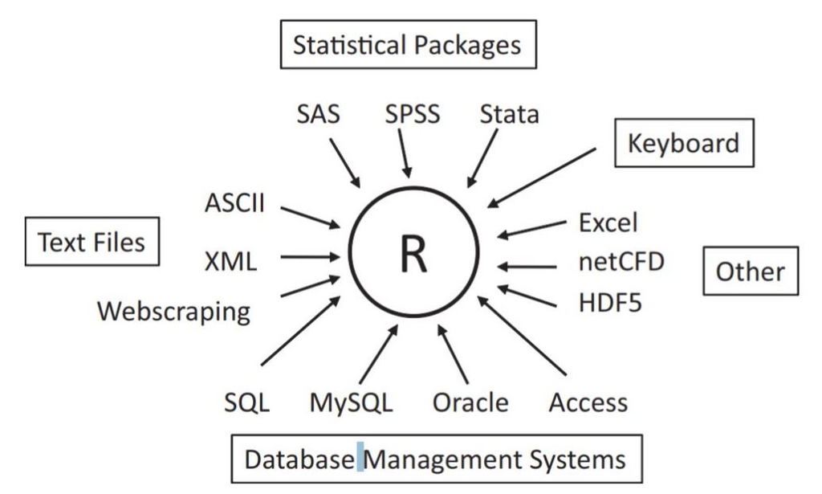

*Fig1. Fontes de importação de dados no R (in [Kabacoff, 2015](https://www.manning.com/books/r-in-action-second-edition)).*

## Estruturas de dados - Bases de dados (cont.)

O R permite a introdução de dados através do teclado  
- No entanto esta não é a opção mais prática

A opção mais comum é simplesmente importar dados noutros formatos:  
- Formato de texto  
- SPSS  
- Excel

*A importação de dados para o R de outros pacotes estatísticos (e.g., SAS ou STATA) é bastante direta.*

## Estruturas de dados - Bases de dados (cont.)

Uma das formas mais fáceis de importar dados para o R é através de documentos em formato de **texto simples**  
- Ex. ficheiros “.CSV” (*Comma Separated Values*)

Para importar dados de ficheiros de texto delimitado usar **read.table()**  
- Esta função cria uma BD no R de formato tabular, a partir de ficheiros de texto  
- Cada linha de texto corresponde uma linha na tabela

#### dataframe <- read.table(“file”, options)

```r
formals(read.table) # the list of function's arguments
?read.table
?formals
```

## Estruturas de dados - Bases de dados (cont.)

Como exemplo vamos usar a BD *bechdel*  
- Esta base de dados inclui os resultados deste teste a 1794 filmes

Esta medida de viés de género considera 3 critérios:  
1. Existem no filme pelo menos duas mulheres com nome definido;  
2. Essas mulheres conversam uma com a outra em algum momento do filme;  
3. Essa conversa não é sobre uma personagem do sexo masculino.

**O filme passa no teste se cumprir este 3 critérios**

*Por exemplo, o filme “The Avengers” tem pelo menos duas personagens do sexo feminino, no entanto essas personagens não conversam uma com a outra. Este filme não cumpre o segundo critério e por isso falha no teste.*

[Mais informações acerca do bechdel test neste link](https://fivethirtyeight.com/features/the-dollar-and-cents-case-against-hollywoods-exclusion-of-women/)

## Estruturas de dados - Bases de dados (cont.)

Importação do ficheiro “bechdel.csv” e criação da base de dados “bechdel”

```r
bechdel <-
  read.table(
    "G:\\My Drive\\FPCEUP\\AtividadeDocente\\R_crash_course\\R crash course_Data\\bechdel.csv",
    header = TRUE,
    sep = ";",
    quote = "\"",
    dec = ".",
    na.strings = " ",
    stringsAsFactors = FALSE,
    colClasses =  c("numeric", "character", "numeric", "factor", "numeric", "numeric", "numeric"),
    fileEncoding="UTF-8-BOM"
  )
```

## Estruturas de dados - Bases de dados (cont.)

Em vez da função genérica **read.table()** podemos recorrer à função **read.csv2()**

- Esta função define vários argumentos por defeito, “poupando” algumas linhas de código

```r
bechdel <-
  read.csv2(
    "G:\\My Drive\\FPCEUP\\AtividadeDocente\\R_crash_course\\R crash course_Data\\bechdel.csv",
    fileEncoding="UTF-8-BOM")
head(bechdel, 2)
```

```
##   movie_year movie_title bechdel_test bechdel_test_binary   budget US_profit
## 1       2013   21 & Over            2                   0 13000000  25682380
## 2       2012    Dredd 3D            5                   1 45658735  13611086
##   Int_Profit
## 1   42195766
## 2   41467257
```

## Estruturas de dados - Bases de dados (cont.)

```r
names(bechdel)
```

```
## [1] "movie_year"          "movie_title"         "bechdel_test"
## [4] "bechdel_test_binary" "budget"              "US_profit"
## [7] "Int_Profit"
```

```r
summary(bechdel)
```

```
##    movie_year   movie_title         bechdel_test   bechdel_test_binary
##  Min.   :1970   Length:1794        Min.   :1.000   Min.   :0.0000
##  1st Qu.:1998   Class :character   1st Qu.:2.000   1st Qu.:0.0000
##  Median :2005   Mode  :character   Median :4.000   Median :0.0000
##  Mean   :2003                      Mean   :3.534   Mean   :0.4487
##  3rd Qu.:2009                      3rd Qu.:5.000   3rd Qu.:1.0000
##  Max.   :2013                      Max.   :5.000   Max.   :1.0000
##                                    NA's   :6       NA's   :20
##      budget            US_profit           Int_Profit
##  Min.   :     8632   Min.   :8.990e+02   Min.   :8.990e+02
##  1st Qu.: 16143738   1st Qu.:2.034e+07   1st Qu.:3.298e+07
##  Median : 36995786   Median :5.543e+07   Median :9.502e+07
##  Mean   : 55619298   Mean   :9.460e+07   Mean   :1.968e+08
##  3rd Qu.: 78664918   3rd Qu.:1.212e+08   3rd Qu.:2.408e+08
##  Max.   :461435929   Max.   :1.772e+09   Max.   :3.172e+09
##  NA's   :18          NA's   :20          NA's   :11
```

## Estruturas de dados - Bases de dados (cont.)

O R permite também importar diretamente de programas estatísticos como o SPSS

- No entanto, para este efeito, teremos que instalar alguns pacotes adicionais

#### instalar o pacote foreign ou o pacotes Hmisc

```r
#install.packages("foreign", "Hmisc")
library(foreign)
library(Hmisc)
tail(ls("package:Hmisc"))
```

```
## [1] "xYplot"          "xySortNoDupNoNA" "yearDays"        "yInch"
## [5] "ynbind"          "zoom"
```

```r
?read.spss
```

## Estruturas de dados - Bases de dados (cont.)

### Importar do SPSS com a função **foreign::read.spss()**

```r
bechdel <- read.spss("G:\\My Drive\\FPCEUP\\AtividadeDocente\\R_crash_course\\R crash course_Data\\bechdel.sav",
                     to.data.frame = TRUE)
```

```r
str(bechdel)
dim(bechdel)
```

```r
bechdel[1234, ]
```

```
##      movie_year
## 1234       2000
##                                                                              movie_title
## 1234 Erin Brockovich
##      bechdel_test bechdel_test_binary   budget US_profit Int_Profit
## 1234           ok           pass test 67645419 169855868  348786874
```

## Estruturas de dados - Bases de dados (cont.)

### Importar do SPSS com a função **hmisc::spss.get()**

```r
bechdel <- spss.get("G:\\My Drive\\FPCEUP\\AtividadeDocente\\R_crash_course\\R crash course_Data\\bechdel.sav")
str(bechdel)
```

```r
head(bechdel, 3)
```

```
##   movie_year
## 1       2013
## 2       2012
## 3       2013
##                                                                           movie_title
## 1 21 & Over
## 2 Dredd 3D
## 3 12 Years a Slave
##   bechdel_test bechdel_test_binary   budget US_profit Int_Profit
## 1      no talk           fail test 13000000  25682380   42195766
## 2           ok           pass test 45658735  13611086   41467257
## 3      no talk           fail test 20000000  53107035  158607035
```

## Funções integradas

## Funções R

### A maioria das funcionalidades do R decorrem da utilização de funções:

- **Built-in Vs. User-defined**
- As funções são um tipo de objeto específicos do R
- Definida por um conjunto de expressões
- Uma função incluí geralmente:
  - Conjunto de argumentos, dentro de parênteses (input)
  - Expressões a ser executar
  - Resultado da função (output)

```r
sample(1:10, 4) # Exemplo de função com dois argumentos
```

```
## [1] 3 9 4 6
```

## Funções R (cont.)

Dois exemplos simples que ilustram a importância das funções…

### Fórmula para cálculo da média

\[\overline{x}=\frac{\sum_{i = 1}^{n} x_{i}} {n}\]

\(\sum_{i = 1}^{n} x_{i}\) = somatório de todos os x  
\({n}\) = número de dados

```r
a <- c(9, 2, 5, 4, 12, 7, 8, 11, 9, 3, 7, 4, 12, 5, 4, 10, 9, 6, 9, 4)
```

## Funções R (cont.)

### Função para cálculo da média

```r
sum(a)
length(a)
sum(a)/length(a)
mean <- sum(a)/length(a)
```

Mais simples, usando função base do R

```r
mean(a)
```

```
## [1] 7
```

## Funções R (cont.)

### Fórmula para cálculo do desvio padrão

\[{S}=\sqrt{ \frac{1}{n-1} {\sum_{i = 1}^{n} (x_{i}-\overline{x})^{2}} }\]

\({n}\) = número de dados  
\(\overline{x}\) = média de x

```r
mean(a) # OR sum(a)/length(a)
(a-mean(a))^2
sum((a-mean(a))^2)
1/(length(a)-1)
1/(length(a)-1)*sum((a-mean(a))^2)
sqrt(1/(length(a)-1)*sum((a-mean(a))^2))
```

## Funções R (cont.)

Mais simples, criando a nossa função

```r
sd_user <- function(a) {
  sqrt(1/(length(a)-1)*sum((a-mean(a))^2))
}
sd_user(a)
```

```
## [1] 3.060788
```

Ou, ainda mais simples, usando função base do R

```r
sd(a)
```

```
## [1] 3.060788
```

## Funções R - Sumário de dados

Vamos exemplificar algumas funções base do R com recurso a BD mtcars

```r
data(mtcars)
class(mtcars) # reports the data format
```

```
## [1] "data.frame"
```

```r
dim(mtcars) # reports data dimensions
```

```
## [1] 32 11
```

```r
names(mtcars) # view variable names
```

```
##  [1] "mpg"  "cyl"  "disp" "hp"   "drat" "wt"   "qsec" "vs"   "am"   "gear"
## [11] "carb"
```

## Funções R - Sumário de dados (cont.)

```r
str(mtcars) # summarizes data structure
```

```
## 'data.frame':    32 obs. of  11 variables:
##  $ mpg : num  21 21 22.8 21.4 18.7 18.1 14.3 24.4 22.8 19.2 ...
##  $ cyl : num  6 6 4 6 8 6 8 4 4 6 ...
##  $ disp: num  160 160 108 258 360 ...
##  $ hp  : num  110 110 93 110 175 105 245 62 95 123 ...
##  $ drat: num  3.9 3.9 3.85 3.08 3.15 2.76 3.21 3.69 3.92 3.92 ...
##  $ wt  : num  2.62 2.88 2.32 3.21 3.44 ...
##  $ qsec: num  16.5 17 18.6 19.4 17 ...
##  $ vs  : num  0 0 1 1 0 1 0 1 1 1 ...
##  $ am  : num  1 1 1 0 0 0 0 0 0 0 ...
##  $ gear: num  4 4 4 3 3 3 3 4 4 4 ...
##  $ carb: num  4 4 1 1 2 1 4 2 2 4 ...
```

```r
head(mtcars) # returns first observations
```

```
##                    mpg cyl disp  hp drat    wt  qsec vs am gear carb
## Mazda RX4         21.0   6  160 110 3.90 2.620 16.46  0  1    4    4
## Mazda RX4 Wag     21.0   6  160 110 3.90 2.875 17.02  0  1    4    4
## Datsun 710        22.8   4  108  93 3.85 2.320 18.61  1  1    4    1
## Hornet 4 Drive    21.4   6  258 110 3.08 3.215 19.44  1  0    3    1
## Hornet Sportabout 18.7   8  360 175 3.15 3.440 17.02  0  0    3    2
## Valiant           18.1   6  225 105 2.76 3.460 20.22  1  0    3    1
```

## Funções R - Sumário de dados (cont.)

```r
mtcars[2,] # returns line 2
```

```
##               mpg cyl disp  hp drat    wt  qsec vs am gear carb
## Mazda RX4 Wag  21   6  160 110  3.9 2.875 17.02  0  1    4    4
```

```r
mtcars[,1] # returns collumn 1
```

```
##  [1] 21.0 21.0 22.8 21.4 18.7 18.1 14.3 24.4 22.8 19.2 17.8 16.4 17.3 15.2 10.4
## [16] 10.4 14.7 32.4 30.4 33.9 21.5 15.5 15.2 13.3 19.2 27.3 26.0 30.4 15.8 19.7
## [31] 15.0 21.4
```

```r
mtcars$mpg # extract column "mpg"
```

```
##  [1] 21.0 21.0 22.8 21.4 18.7 18.1 14.3 24.4 22.8 19.2 17.8 16.4 17.3 15.2 10.4
## [16] 10.4 14.7 32.4 30.4 33.9 21.5 15.5 15.2 13.3 19.2 27.3 26.0 30.4 15.8 19.7
## [31] 15.0 21.4
```

## Funções R - Sumário de dados (cont.)

```r
summary(mtcars[,1:8]) # summarize R objects
```

```
##       mpg             cyl             disp             hp
##  Min.   :10.40   Min.   :4.000   Min.   : 71.1   Min.   : 52.0
##  1st Qu.:15.43   1st Qu.:4.000   1st Qu.:120.8   1st Qu.: 96.5
##  Median :19.20   Median :6.000   Median :196.3   Median :123.0
##  Mean   :20.09   Mean   :6.188   Mean   :230.7   Mean   :146.7
##  3rd Qu.:22.80   3rd Qu.:8.000   3rd Qu.:326.0   3rd Qu.:180.0
##  Max.   :33.90   Max.   :8.000   Max.   :472.0   Max.   :335.0
##       drat             wt             qsec             vs
##  Min.   :2.760   Min.   :1.513   Min.   :14.50   Min.   :0.0000
##  1st Qu.:3.080   1st Qu.:2.581   1st Qu.:16.89   1st Qu.:0.0000
##  Median :3.695   Median :3.325   Median :17.71   Median :0.0000
##  Mean   :3.597   Mean   :3.217   Mean   :17.85   Mean   :0.4375
##  3rd Qu.:3.920   3rd Qu.:3.610   3rd Qu.:18.90   3rd Qu.:1.0000
##  Max.   :4.930   Max.   :5.424   Max.   :22.90   Max.   :1.0000
```

## Funções R - Sumário de dados (cont.)

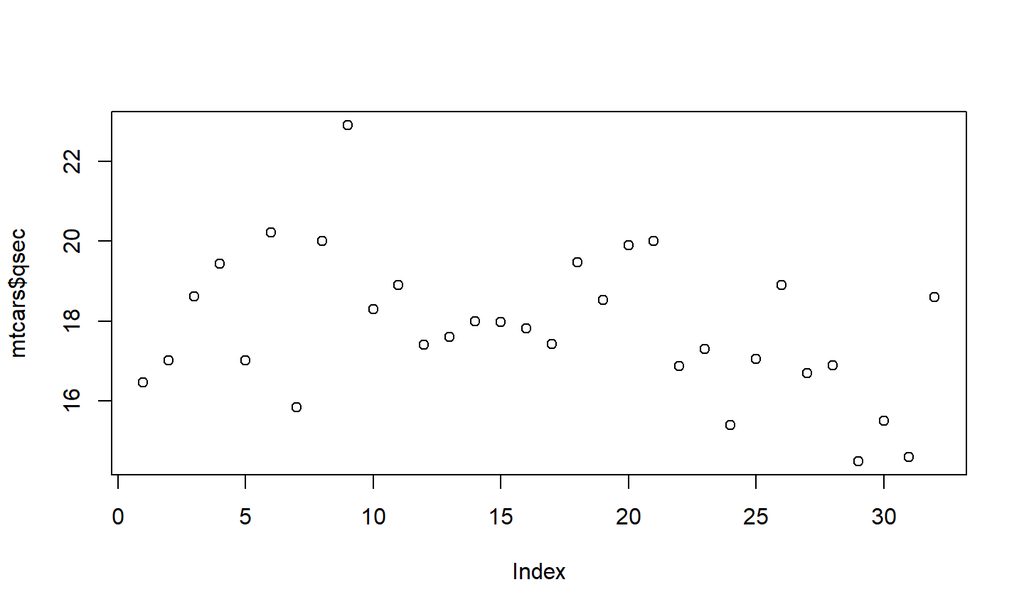

```r
plot(mtcars$qsec) # plot 1/4 mile time
```

## Funções R - Sumário de dados (cont.)

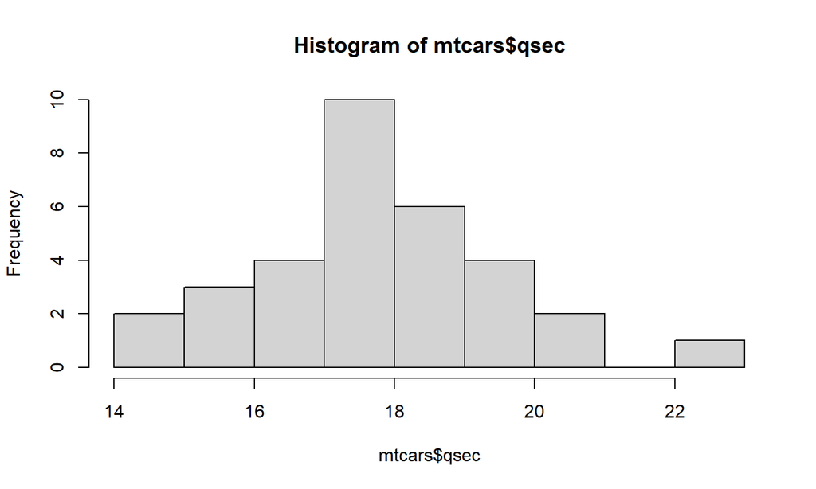

```r
hist(mtcars$qsec) # histogram for 1/4 mile time
```